# 4_MLP

#### AND Example

```python
X = [[0., 0.],
     [0., 1.],
     [1., 0.],
     [1., 1.]]
```

```python
target = [0, 0, 0, 1]
```

```python
and_clf = MLP(2, .25)
and_clf.fit(X, target, 5001)
```

```
Iteration:  5001  Objective:  4.910941416521178e-05
```

```python
and_clf.predict(X)
```

```
array([[0.00027716],
       [0.0063409 ],
       [0.00760784],
       [0.99981568]])
```

```python
and_clf.confusion_matrix(X, target, summary=False)
```

```
array([[3., 0.],
       [0., 1.]])
```

#### XOR Example

```python
target = [0., 1., 1., 0.]
```

```python
xor_clf = MLP(2, .25)
xor_clf.fit(X, target, 5001)
```

```
Iteration:  5001  Objective:  0.0001579886898386745
```

```python
xor_clf.predict()
```

```
array([[0.01152819],
       [0.9998623 ],
       [0.99986226],
       [0.01352668]])
```

#### Practical Considerations

- Data Preparation
- How much training data?
- Number of hidden layers?
- Overfitting
  - Stop before overfitting
  - How do we figure this out?

#### Training, Testing, and Validation

- To evaluate our training, we may use the **holdout method**
- We set aside some data from the training training set
- This data is called the **test set**
- It reduces the data available for training
- We also want to try to evaluate how well the learning is going during training
- For this we use a **validation set** (the same idea as **cross-validation** in statistics)
- We might split the data into training:test:validation according to 50:25:25 or 60:20:20
- This is called a **three-way data split**
- You may need to be sure that the data is randomly ordered before splitting
- All data preprocessing occurs before splitting

#### Other Resampling Methods

- It is common to have too little data for a proper training-testing-validation split
- We might also want to avoid getting a small error rate because of "bad" random split
- At the expense of more computations, we may try cross-validation
  - Random Subsampling
  - K-Fold Cross-Validation
  - Leave-one-out Cross Validation
- The idea is to randomly partition the dataset into $K$ subsets
- Use one of the $K$ subsets as a validation set and train on the others
- Do this again, leaving out another subset for validation, until all are left-out for validation
- Use the model with the smallest validation error

#### When to Stop?

- So far we have trained a network for a fixed number of iterations
- This is never what you really want to do
- You run the potential for both over- and under-fitting the data.
- We can use the **validation set** to determine when to stop
- Run the network for some fixed number of iterations and then evaluate on the validation set
- Run for a few more iterations, then start over
- At some point the error on the validation set will start to increase
- This is when we stop. Unsurprisingly, this is called **early stopping**

#### Example: Regression

- First let's generate some data
- Then we'll use the MLP to try to uncover the function (or data generating process)

```python
np.random.seed(12345)
x = np.linspace(0, 1, 40)[:,None] # make 2D
t = (np.sin(2*np.pi*x) +
     np.cos(4*np.pi*x) +
     np.random.normal(0, .2, size=(40,1)))
x = (x - .5)*2
```

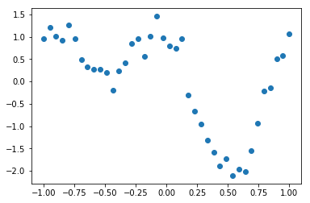

```python
fig, ax = plt.subplots()
ax.plot(x, t, 'o');
```

Split into 50:25:25

```python
train = x[::2]
test = x[1::4]
validate = x[3::4]

train_target = t[::2]
test_target = t[1::4]
validate_target = t[3::4]
```

- We don't know how many hidden neurons, we'll need, so let's try 3.
- We will run this for 100 iterations

```python
net = MLP(3, .25, outtype="linear")
net.fit(train, train_target, 100)
```

```
Iteration:  100  Objective:  5.786910842467972
```

- First let's decide how long to train the network

```python
net.earlystopping(train, train_target, validate, validate_target)
```

```
1
Iteration:  100  Objective:  6.241007391835198
2
Iteration:  100  Objective:  5.1493054980002455
3
Iteration:  100  Objective:  3.9945234208676976
4
Iteration:  100  Objective:  1.67441528288402
5
Iteration:  100  Objective:  1.2168240089318705
6
Iteration:  100  Objective:  1.1924711010739992
7
Iteration:  100  Objective:  1.186424764390006
8
Iteration:  100  Objective:  1.183010536798169
9
Iteration:  100  Objective:  1.180200380024946
10
Iteration:  100  Objective:  1.1774491050873248
Stopped in 10 iterations [0.8507868807922389, 0.850268223033572, 0.8505268256854234]
```

```
0.8507868807922389
```

```python
nhiddens = [1, 2, 3, 5, 10, 25, 50, 100]
all_errors = []
nruns = 10

for nhidden in nhiddens:
    errors = []
    mlp = MLP(nhidden, .25, outtype="linear")
    for i in range(nruns):
        error = mlp.earlystopping(train, train_target, validate, validate_target, disp=False)
        errors.append(error)
    all_errors.append(errors)
```

```python
all_errors = np.array(all_errors)
print("        n              mean          std            min            max")
print(np.column_stack((nhiddens, all_errors.mean(1), all_errors.std(1), all_errors.min(1), all_errors.max(1))))
```

```
        n              mean          std            min            max
[[  1.           4.019718     0.00034095   4.01938892   4.02019862]
 [  2.           0.84192133   0.00996038   0.82963537   0.85855558]
 [  3.           0.82634142   0.0123594    0.8054791    0.83974172]
 [  5.           0.39752657   0.13668826   0.3406321    0.80633263]
 [ 10.           0.34833686   0.01600634   0.33610672   0.38438247]
 [ 25.           0.354494     0.01023725   0.34089938   0.37053218]
 [ 50.           0.36033464   0.0050578    0.34996736   0.36804985]
 [100.           5.27394619   0.00000128   5.27394386   5.27394715]]
```

#### scikit-learn for training, testing, and cross-validation

[Documentation](http://scikit-learn.org/stable/modules/classes.html#module-sklearn.cross_validation)

```python
#from sklearn import cross_validation
#from sklearn.model_selection import cross_validate
a, b = np.arange(16).reshape((8, 2)), np.arange(8)
```

```python
print(a)
print(b)
```

[output not shown]

```python
from sklearn import model_selection
(a_train,
 a_test,
 b_train,
 b_test) = model_selection.train_test_split(a, b,
                                     train_size=.75,
                                     random_state=123)
```

```python
a_train, b_train
```

```python
a_test, b_test
```

**Aside:** Python Generators

**K-Folds Cross-Validation**

- The data is split into $K$ consecutive "folds"
- Of the K subsamples, retain a single subsample as a validation set
- Use the other k-1 subsamples as a training set
- Gives indices to split the data into train and test sets
- All observations are used as both training and test samples

```python
X = np.array([[1, 2], [3, 4], [1, 2], [3, 4]])
y = np.array([1, 2, 3, 4])
kf = model_selection.KFold(10, n_splits=5)

for train_index, test_index in kf:
    print("TRAIN:", train_index, "TEST:", test_index)
```

```python
kf = model_selection.KFold(10, n_folds=5, shuffle=True)

for train_index, test_index in kf:
    print("TRAIN:", train_index, "TEST:", test_index)
```

#### Example: Classification

```python
from sklearn.datasets import load_iris

data = load_iris()
```

```python
print(data.DESCR)
```

```
.. _iris_dataset:

Iris plants dataset
--------------------

**Data Set Characteristics:**

    :Number of Instances: 150 (50 in each of three classes)
    :Number of Attributes: 4 numeric, predictive attributes and the class
    :Attribute Information:
        - sepal length in cm
        - sepal width in cm
        - petal length in cm
        - petal width in cm
        - class:
                - Iris-Setosa
                - Iris-Versicolour
                - Iris-Virginica

    :Summary Statistics:

    ============== ==== ==== ======= ===== ====================
                    Min  Max   Mean    SD   Class Correlation
    ============== ==== ==== ======= ===== ====================
    sepal length:   4.3  7.9   5.84   0.83    0.7826
    sepal width:    2.0  4.4   3.05   0.43   -0.4194
    petal length:   1.0  6.9   3.76   1.76    0.9490  (high!)
    petal width:    0.1  2.5   1.20   0.76    0.9565  (high!)
    ============== ==== ==== ======= ===== ====================

    :Missing Attribute Values: None
    :Class Distribution: 33.3% for each of 3 classes.
    :Creator: R.A. Fisher
    :Donor: Michael Marshall (MARSHALL%PLU@io.arc.nasa.gov)
    :Date: July, 1988

The famous Iris database, first used by Sir R.A. Fisher. The dataset is taken
from Fisher's paper. Note that it's the same as in R, but not as in the UCI
Machine Learning Repository, which has two wrong data points.

```

[output cut: 8 more lines]

```

   - Fisher, R.A. "The use of multiple measurements in taxonomic problems"
     Annual Eugenics, 7, Part II, 179-188 (1936); also in "Contributions to
     Mathematical Statistics" (John Wiley, NY, 1950).
   - Duda, R.O., & Hart, P.E. (1973) Pattern Classification and Scene Analysis.
     (Q327.D83) John Wiley & Sons.  ISBN 0-471-22361-1.  See page 218.
   - Dasarathy, B.V. (1980) "Nosing Around the Neighborhood: A New System
     Structure and Classification Rule for Recognition in Partially Exposed
     Environments".  IEEE Transactions on Pattern Analysis and Machine
     Intelligence, Vol. PAMI-2, No. 1, 67-71.
   - Gates, G.W. (1972) "The Reduced Nearest Neighbor Rule".  IEEE Transactions
     on Information Theory, May 1972, 431-433.
   - See also: 1988 MLC Proceedings, 54-64.  Cheeseman et al"s AUTOCLASS II
     conceptual clustering system finds 3 classes in the data.
   - Many, many more ...
```

You can read much more about the dataset [here](http://en.wikipedia.org/wiki/Iris_flower_data_set)

Normalize the data

```python
# demean
X = data.data - data.data.mean(0)
# normalize by maximum
X /= X.max(0)
```

```python
data.target
```

```
array([0, 0, 0, 0, 0, 0, 0, 0, 0, 0, 0, 0, 0, 0, 0, 0, 0, 0, 0, 0, 0, 0,
       0, 0, 0, 0, 0, 0, 0, 0, 0, 0, 0, 0, 0, 0, 0, 0, 0, 0, 0, 0, 0, 0,
       0, 0, 0, 0, 0, 0, 1, 1, 1, 1, 1, 1, 1, 1, 1, 1, 1, 1, 1, 1, 1, 1,
       1, 1, 1, 1, 1, 1, 1, 1, 1, 1, 1, 1, 1, 1, 1, 1, 1, 1, 1, 1, 1, 1,
       1, 1, 1, 1, 1, 1, 1, 1, 1, 1, 1, 1, 2, 2, 2, 2, 2, 2, 2, 2, 2, 2,
       2, 2, 2, 2, 2, 2, 2, 2, 2, 2, 2, 2, 2, 2, 2, 2, 2, 2, 2, 2, 2, 2,
       2, 2, 2, 2, 2, 2, 2, 2, 2, 2, 2, 2, 2, 2, 2, 2, 2, 2])
```

We need to put this into 1-of-N encoding

```python
target = np.zeros((len(X), 3))
target[np.arange(len(X)),data.target] = 1
```

```python
target[:10]
```

```
array([[1., 0., 0.],
       [1., 0., 0.],
       [1., 0., 0.],
       [1., 0., 0.],
       [1., 0., 0.],
       [1., 0., 0.],
       [1., 0., 0.],
       [1., 0., 0.],
       [1., 0., 0.],
       [1., 0., 0.]])
```

We are going to use train_test_split to split the data up into training, testing, and validation sets

```python
(feature_train, feature_test,
 target_train, target_test) = model_selection.train_test_split(X, target, test_size=.25)
```

```python
target_train.mean(0)
```

```
array([0.3125    , 0.34821429, 0.33928571])
```

If you need to split based on maintaining the same percentage of the target labels, you can use StratifiedKFold

We can now split the training data into training and validation sets

```python
(feature_train, feature_validate,
 target_train, target_validate) = model_selection.train_test_split(feature_train,
                                                                    target_train,
                                                                    test_size=.33)
```

```python
net = MLP(5, .1, outtype="softmax")
net.earlystopping(feature_train, target_train, feature_validate,
                  target_validate, disp=False)
```

```
0.8346276748125668
```

```python
net.confusion_matrix(feature_test, target_test)
```

```
97.36842105263158
```

```python
net.confusion_matrix(feature_test, target_test, summary=False)
```

```
array([[15.,  0.,  0.],
       [ 0., 10.,  1.],
       [ 0.,  0., 12.]])
```

#### Back-Propagation Derivation

- The output, $y$, is a function of $x$, $g(\cdot)$, and the weights
- The weights will be denoted $v$ and $w$ for the first and second layers
- $i$ is the index over the input nodes, $j$ is the index over the hidden layer neurons, $k$ is the index over the output neurons
- First let's write the error function

$$\begin{aligned}E(\boldsymbol{w}) & =\frac{1}{2}\sum_{k=1}^N\left(t_k-y_k\right)^2 \cr & = \frac{1}{2}\sum_k{\left[t_k-g\left(\sum_j w_{jk}a_j \right)\right]^2}\end{aligned}$$

where $a_j$ is the output from the hidden layer neurons

- For the moment, let's ignore the hidden layer and work with the perceptron

$$\begin{aligned}E(\boldsymbol{w}) & =\frac{1}{2}\sum_{k=1}^N\left(t_k-y_k\right)^2 \cr & = \frac{1}{2}\sum_k{\left[t_k-g\left(\sum_j w_{jk}x_j \right)\right]^2}\end{aligned}$$

- Since we will use gradient descent, unsurprisingly, we will need the gradient
- Let's remind ourselves, what is the gradient again?
- Recall that $g$ was the binary activation function and, thus, not differentiable, so we ignore it in the below
- We adjust the weights to reduce the errors, thus we need

$$\begin{aligned}\frac{\partial E}{\partial w_{ik}} & = \frac{\partial}{\partial w_{ik}}\left(\frac{1}{2}\sum_k\left(t_k-\sum_j w_{jk}x_j\right)^2\right) \cr & = \frac{1}{2}\sum_k2(t_k-y_k)\frac{\partial}{\partial w_{ik}}\left(t_k-\sum_j w_{jk}x_j\right) \cr \end{aligned} $$

note that

$$\frac{\partial t_k}{\partial w_{ik}}=0$$

and

$\frac{\partial}{\partial w_{ik}}\sum_jw_{jk}x_j$

is only non-zero when $i=j$, thus

$$\frac{\partial}{\partial w_{ik}}=x_i$$

so that we have

$$\begin{aligned}\frac{\partial E}{\partial w_{ik}} & = \sum_k(t_k-y_k)\left(-x_i\right) \end{aligned} $$

To make our errors smaller, we follow the gradient "downhill" such that (including the learning rate)

$$w_{ik}\leftarrow w_{ik}+\eta(t_k-y_k)x_i$$

#### Working with the Activation Function

- From the above, it is clear that we need a differentiable $g$ to obtain $\frac{\partial g}{\partial w_{ik}}$ $$a = g(h)=\frac{1}{1+e^{-\beta h}}$$
- The derivative of $g$ has a simple form $$\begin{aligned} g^{\prime}(h) & = \frac{d}{dh}\frac{1}{1+e^{-\beta h}} \cr & = \frac{d}{dh}(1+e^{-\beta h})^{-1} \cr & = -(1+e^{-\beta h})^{-2}(-\beta e^{-\beta h}) \cr & = \frac{\beta e^{-\beta h}}{(1+e^{-\beta h})^{2}} \cr & = \beta\frac{1}{1+e^{-\beta h}}\frac{ e^{-\beta h}}{1+e^{-\beta h}} \cr & = \beta\frac{1}{1+e^{-\beta h}}\left(\frac{1 + e^{-\beta h} - 1}{1+e^{-\beta h}}\right) \cr & = \beta g(h)(1-g(h)) \cr & = \beta a(1-a) \cr \end{aligned} $$

#### Back-Propagation of Error

- To use gradient-descent in the MLP, we need the partials of the errors with respect to each weight

$$\frac{\partial E}{\partial w_{jk}}=\frac{\partial E}{\partial h_k}\frac{\partial h_k}{\partial w_{jk}}$$

where $h_k=\sum_lw_{lk}a_l$ is the input to output-layer neuron $k$

- Ie., this is the weighted average of the activations of the hidden layer neurons, using second-layer weights
- Taking the second part of partials, we have

$$\begin{aligned} {\partial h_k}\frac{\partial h_k}{\partial w_{jk}} & =\frac{\partial \sum_l w_{lk}a_l}{\partial w_{jk}} \cr & = \sum_l\frac{\partial w_{lk}a_l}{\partial w_{jk}} \cr & = a_j \end{aligned} $$

- The first term is referred to as the **error** or **delta term**

$$\delta_0 = \frac{\partial E}{\partial h_k}$$

- We need to unpack this, because we don't know the inputs just the outputs

$$\delta_0 = \frac{\partial E}{\partial h_k}= \frac{\partial E}{\partial y_k}\frac{\partial y_k}{\partial h_k}$$

where the output of the output-layer neuron $k$

$$y_k = g(h_k)=g\left(\sum_j w_{jk}a_j\right)$$

Plugging-in the derivatives we already have for $\delta_0$ gives

$$\begin{aligned} \delta_0 & = \frac{\partial E}{\partial g(h_k)}\frac{\partial g(h_k)}{\partial h_k} \cr & = \frac{\partial}{\partial g(h_k)}\left[\frac{1}{2}\sum_k{\left(t_k-g\left(\sum_j w_{jk}x_j\right)\right)}\right] \frac{\partial g(h_k)}{\partial h_k} \cr & = (g(h_k)-t_k)g^{\prime}(h_k) \cr & = (y_k - t_k)g^{\prime}(h_k) \end{aligned} $$

We already have $g^\prime(h_k)$ so we can put it all together to give the update step for the second-layer weights

$$w_{jk}\leftarrow w_{jk} - \eta \frac{\partial E}{\partial w_{jk}}$$

The missing piece is

$$\begin{aligned} \frac{\partial E}{\partial w_{jk}} &= \delta_0a_j \cr &= (y_k - t_k)y_k(1-y_k)a_j \end{aligned}$$

#### First layer weights

- Now we need the first layer weights - the hidden weights $v_{jk}$
- Remember we are going *back* propagation

$$\begin{aligned} \delta_h &= \sum_k \frac{\partial E}{\partial h_k} \frac{\partial h_k}{\partial h_j} \cr &= \sum_k\delta_0 \frac{\partial h_k}{\partial h_j} \end{aligned}$$

- One thing to keep in mind, inputs to the output layer neurons come from the activation of the weighted average hidden layer neurons, using the second-layer weights

$$h_k = g(\sum_lw_{lk}h_l)$$

and

$$\frac{\partial h_k}{\partial h_j}=\frac{\partial g(\sum_l w_{lk}h_l)}{h_j}$$

Noting that $\frac{\partial h_i}{\partial h_j} = 0$ if $i\neq l$

$$\begin{aligned} \frac{\partial h_k}{\partial h_j}&=w_{jk}g^{\prime}(a_j) \cr &=w_{jk}a_j(1-a_j) \end{aligned}$$

This gives a **delta term**

$$\delta_h = a_j(1-a_j)\sum_k \delta_0 w_{jk}$$

So the update rule $v_{ij}\leftarrow v_{ij} - \eta\frac{\partial E}{\partial v_{ij}}$ needs

$$\frac{\partial E}{\partial v_{ij}} = a_j(1-a_j)(\sum_k \delta_0w_{jk})x_i$$